# Assignment 2: Task 1

Author

Sam Lance

Published

January 25, 2025

```r
library(ggplot2)
library(tidyverse)
library(here)
library(janitor)
library(patchwork)
library(lubridate)
library(forcats)
library(gghighlight)
library(stringr)
```

## 1 Loading the Data

```r
#READ IN DATA
county_og <- read.csv(here("t2_data", "NRI_Table_Counties.csv"))

#CLEAN/ WRANGLE DATA
county_mod <- county_og |>
  clean_names() |> #put all in snake case
  filter(!(state %in% c("American Samoa", "Guam", "Northern Mariana Islands", "Puerto Rico", "Virgin Islands", "District of Columbia"))) |> #filter out territories
  group_by(state) |> #group by state
  summarize(avg_risk = mean(risk_score)) |> #get the mean of the risk score
  mutate(state = fct_reorder(state, avg_risk)) |> #put in state order by risk score
  arrange(avg_risk)
```

## 2 Visualization 1

### 2.1 **Psuedocode**

- Group_by state -> summarize to find the average risk score for each state
- Create a lollipop or column graph of risk scores
- GGhighlight to highlight California in particular

### 2.2 **Creating Plot**

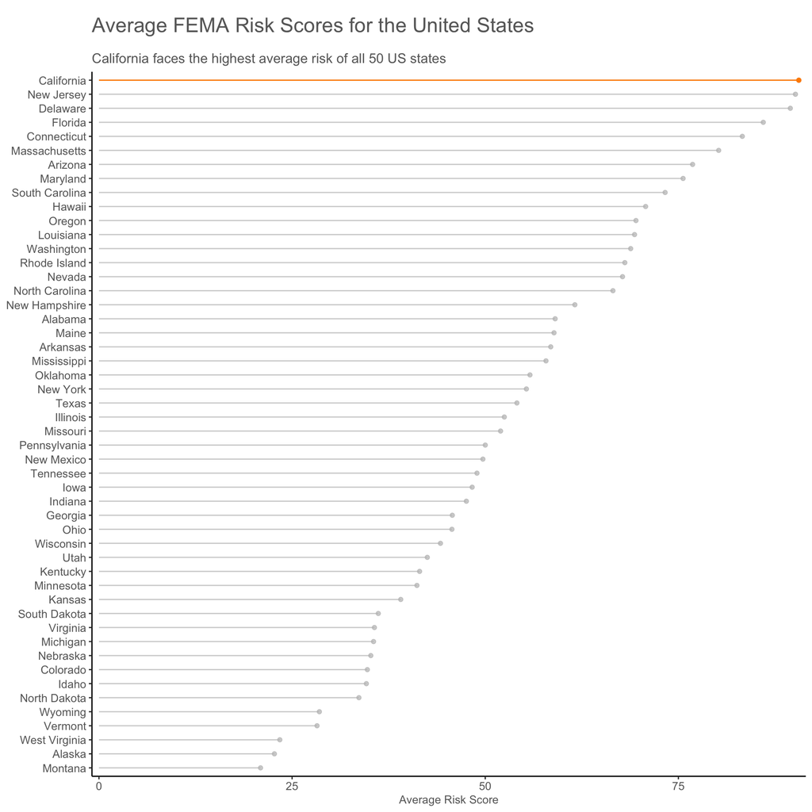

Figure 1: Data: FEMA National Risk Index (2023 Release) Accessed 1/30/25

```r
#CREATE PLOT
county_mod |>
  ggplot(aes(x=state, y=avg_risk)) +
  geom_segment(aes(y=0, yend=avg_risk), color = "darkorange") + #geom_segment for lolly
  geom_point(color = "darkorange") + #geom point for lolly
  gghighlight(state == "California", use_direct_label = FALSE) + #highlight CA
  labs(y = "Average Risk Score",
       x = NULL,
       title = "Average FEMA Risk Scores for the United States",
       subtitle = "California faces the highest average risk of all 50 US states") +
  scale_y_continuous(expand = expansion(mult = 0.01)) + #expand to y axis almost completely
  theme_classic() + #premade theme
  coord_flip() + #flip axes
  theme(
    axis.text = element_text(color = "#686868", size = 10),
    axis.title = element_text(color = "#686868", size = 10),
    plot.subtitle = element_text(color = "#686868", size = 12),
    plot.title = element_text(hjust = 0, color = "#686868", size = 18,
                              margin = margin(t = 10, r = 0, b = 15, l = 0))
  ) #customize text and colors
```

### 2.3 Answering Questions

#### 2.3.1 What are your variables of interest and what kinds of data (e.g. numeric, categorical, ordered, etc.) are they (a bullet point list is fine)?

The variables I used were risk scores for each county (numeric) and the state name (character).

#### 2.3.2 How did you decide which type of graphic form was best suited for answering the question? What alternative graphic forms could you have used instead? Why did you settle on this particular graphic form

I wanted to be able to visually see which states had the largest risk, which is best done through a comparison of lengths. This left me deciding between a bar chart with geom_col or a lollipop chart, but I eventually settled on lollipop since there were so many states. I wanted to remove the bulk in the chart a bar chart could have, so I picked the more slender option.

#### 2.3.3 What modifications did you make to this viz to make it more easily readable?

I changed the height and width of my plot to make my labels have more space, changed the font sizes to allow for better readability, ordered my states from highest to lowest risk, and finally highlighted our state of interest, California.

#### 2.3.4 Is there anything you wanted to implement, but didn’t know how? If so, please describe?

I wanted to find a way to describe the variance between the counties, but with so many states I was having a hard time. A possible solution would have been to look at the top or bottom 3-5 states and do a position = dodge bar plot but for this assignment I felt this would not answer the desired question.

## 3 Visualization 2

### 3.1 Loading Data

NOTE: Struggled to load the data with API key, got data from Liv Hemond :)

```r
# #.........see all available ACS variables + descriptions.........
# acs_vars <- tidycensus::load_variables(year = 2023,
#                                        dataset = "acs1")
#
# #..................import race & ethnicity data..................
# race_ethnicity <- tidycensus::get_acs(
#   geography = "county",
#   survey = "acs1",
#   variables = c("B01003_001", "B02001_002", "B02001_003",
#                 "B02001_004", "B02001_005", "B02001_006",
#                 "B02001_007", "B02001_008", "B03002_012",
#                 "B03002_002"),
#   state = "CA",
#   year = 2023) |>
#   dplyr::left_join(acs_vars, by = dplyr::join_by(variable == name)) # join variable descriptions (so we know what's what!)
```

### 3.2 Cleaning Data

```r
#OLD CODE - DO NOT GRADE
risk_counties <- county_og |>
  clean_names() |> #snake case
  filter(state == "California") |> #only want CA counties
  select("county", "risk_score") #pick county + risk score

#LOAD RACE DATA
race_eth_og <- read.csv(here("t2_data", "ACS-race-ethnicity.csv"))

#CREATE POPULATION DF
population <- race_eth_og |>
  filter(concept == "Total Population") #create a df of just the population for later use

#CLEAN RACE DATA
race_eth_mod <- race_eth_og |>
  clean_names() |>
  filter(concept == "Race") |> #don't want total pop, just race
  mutate(race = str_remove(label, "Estimate!!Total:!!"), #cleaning up the text in the columns
         county = str_remove(name, " County, California"),
         race = str_replace(race, "alone", ""),
         race = str_remove(race, ":")) |>
  select("race", "county", "estimate") |> #select desired columns
  full_join(risk_counties) #join to the risk data by county
```

```r
#RE-CLEAN COUNTY DATA
risk_counties_2 <- county_og |>
  clean_names() |> #snake case
  filter(state == "California") |> #only want CA counties
  select("county", "risk_ratng") #pick county + risk score

#CLEAN RACE DATA
race_eth_mod_attempt2 <- race_eth_og |>
  clean_names() |>
  filter(concept == "Race") |> #don't want total pop, just race
  mutate(race = str_remove(label, "Estimate!!Total:!!"), #cleaning up the text in the columns
         county = str_remove(name, " County, California"),
         race = str_replace(race, "alone", ""),
         race = str_remove(race, ":")) |>
  select("race", "county", "estimate")  |>#select desired columns
  full_join(risk_counties_2) |> #join to the risk data by county
  drop_na() |>
  mutate(risk_ordered = fct_relevel(risk_ratng, "Relatively Moderate", "Relatively High", "Very High")) |>
  arrange(risk_ordered)
```

### 3.3 Creating Plot

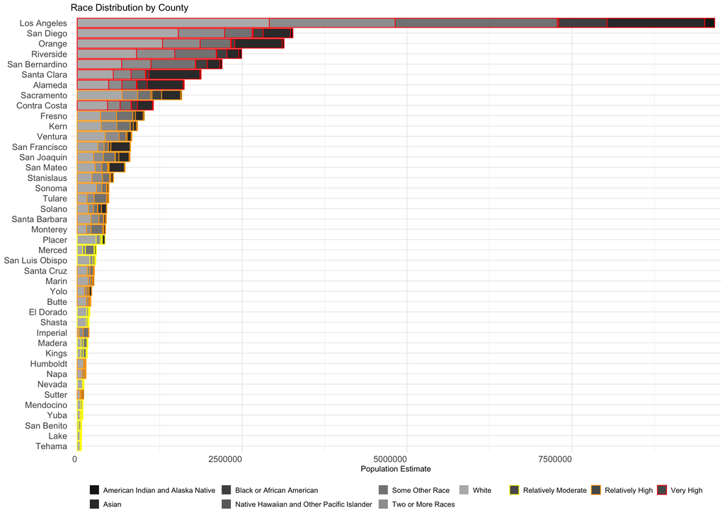

Data: FEMA National Risk Index (2023 Release) and the US Census Bureau’s American Community Survey Accessed 1/30/25

```r
ggplot(race_eth_mod_attempt2) +
  geom_col(aes(x = reorder(county, estimate), y = estimate, fill = race, color = risk_ordered)) +  #reordering by estimate, adding outline of risk by category
  labs(
    title = "Race Distribution by County",
    x = "County",
    y = "Population Estimate",
    fill = "Race") +
  scale_fill_manual(values = c("#1C1C1C", "#363636",  "#505050",  "#6A6A6A","#848484",
  "#9E9E9E", "#B8B8B8",  "#D2D2D2")) + #setting fill colors
  scale_color_manual(values = c("yellow", "orange", "red")) + #setting outline colors
  scale_y_continuous(expand = expansion(mult = 0.01)) + #expand to y axis almost completely
  coord_flip() + #flip axes
  theme_minimal() +
  theme(
    axis.text.x = element_text(hjust = 1, size = 12),
    axis.text.y = element_text(size = 12),
    axis.title.y = element_blank(),
    legend.position = "bottom",
    legend.title = element_blank(),
    legend.text = element_text(size = 10),
    legend.key.size = unit(0.5, 'cm')
  )
```

```r
#try text font fill and color plot by the layers
```

### 3.4 Answering Questions

#### 3.4.1 What are your variables of interest and what kinds of data (e.g. numeric, categorical, ordered, etc.) are they (a bullet point list is fine)?

This chart utilizes the following data:

- Estimate - numeric data of the amount of people of a specific racial group in a county
- County - categorical data of the counties in California
- Risk Rating - categorical data of the risk rating of a specific county in California (moderate, high, very high)

#### 3.4.2 How did you decide which type of graphic form was best suited for answering the question? What alternative graphic forms could you have used instead? Why did you settle on this particular graphic form?

I struggled to find a graphic form to represent this data, as the risk scores were by county and not by racial group for that county. With that in mind, since I had the populations I thought it would be best to do a stacked bar chart to show the general racial makeup of each county in California, with the label colors showing the overall risk for that county. If I did have risk scores for each group for each county, I would have taken an average for each racial group and created a horizontal bar chart.

#### 3.4.3 What modifications did you make to this viz to make it more easily readable?

I expanded the size of my figure since there is a lot of data to showcase, and tried to minimize the amount of color so the overall message of the graph would not be be lost.

#### 3.4.4 Is there anything you wanted to implement, but didn’t know how? If so, please describe.

Instead of coloring the labels, I wanted to have an transparent layer over the bars of the same length so it has a thin wash of the risk color over the gray. Unfortunately I could not do this within the time frame of this project.